# Notebook

## Python Code

### 30_create_earthquake_timeseries.ipynb

**This script enriches the earthquake dataset with seismic parameter and creates the final timeseries for further usage.** The main parts of the routines were developed in previous courses at the University of London by the same author (Mohr, 2021, 2023, 2024a) and have been further refined to meet the needs of this MSc thesis project/research. However, the code has been updated to comply with the latest requirements and package interdependencies. Some comments will be included in this Jupyter Notebook, and the code contains several inline comments. For details on the project/research itself, refer to the appropriate document.

#### References (for this script)

*Mohr, S. (2021) Regional Spatial Clusters of Earthquakes at the Pacific Ring of Fire: Analysing Data from the USGS ANSS ComCat and Building Regional Spatial Clusters. DSM020, Python, examined coursework cw1. University of London.*

*Mohr, S. (2023) Clustering of Earthquakes on a Worldwide Scale with the Help of Big Data Machine Learning Methods. DSM010, Big Data, examined coursework cw2. University of London.*

*Mohr, S. (2024a) Comparing Different Tectonic Setups Considering Publicly Available Basic Earthquake’s Data. DSM050, Data Visualisation, examined coursework cw1. University of London.*

#### History

```
250104 Generation from previous courseworks at the UoL, setup basic logging, read dataset, save dataset,
       improve error handling when inserting new columns, check docstrings
250108 Restricting to study area (if necessary), generating timeseries, saving and loading timeseries,
       make procedures for saving and loading, make loops to handle large amounts of timeseries,
       change everything to aggregated multivariate timeseries
250109 Completely change everything to the 4 multivariate timeseries, move functions to other scripts,
       delete old DMWMY-time series stuff, check temporal fitting to timespan, basic outlier detection with
       isolation forest, make procedures for outlier detection and handling, use datetime64 for loaded datasets,
       improved figure for all freq of all timeseries, moved analyze_outliers
250114 Rename 'size' to 'count'
250120 Switching to parameters.py, adding selectable cluster directory, changing all directories
250125 Integrating new version of save_dataset
```

#### Todo

```
./.
```

## Preparing the environment

### System information

```python
# which python installation and version are we using here?
print('\n******* Python Info ***********')
!which python
!python --version

# show some CPU and RAM info
print('\n******* CPU Info ***********')
!lscpu
print('\n******* RAM Info (in GB) ***********')
!free -g
```

```
******* Python Info ***********
/bin/python
Python 3.8.10

******* CPU Info ***********
Architecture:                       x86_64
CPU op-mode(s):                     32-bit, 64-bit
Byte Order:                         Little Endian
Address sizes:                      46 bits physical, 48 bits virtual
CPU(s):                             64
On-line CPU(s) list:                0-63
Thread(s) per core:                 2
Core(s) per socket:                 8
Socket(s):                          4
NUMA node(s):                       4
Vendor ID:                          GenuineIntel
CPU family:                         6
Model:                              85
Model name:                         Intel(R) Xeon(R) Gold 6234 CPU @ 3.30GHz
Stepping:                           7
CPU MHz:                            1200.059
CPU max MHz:                        4000.0000
CPU min MHz:                        1200.0000
BogoMIPS:                           6600.00
Virtualization:                     VT-x
L1d cache:                          1 MiB
L1i cache:                          1 MiB
L2 cache:                           32 MiB
L3 cache:                           99 MiB
NUMA node0 CPU(s):                  0,4,8,12,16,20,24,28,32,36,40,44,48,52,56,60
NUMA node1 CPU(s):                  1,5,9,13,17,21,25,29,33,37,41,45,49,53,57,61
NUMA node2 CPU(s):                  2,6,10,14,18,22,26,30,34,38,42,46,50,54,58,6
                                    2
NUMA node3 CPU(s):                  3,7,11,15,19,23,27,31,35,39,43,47,51,55,59,6
                                    3
Vulnerability Gather data sampling: Mitigation; Microcode
Vulnerability Itlb multihit:        KVM: Mitigation: Split huge pages
Vulnerability L1tf:                 Not affected
Vulnerability Mds:                  Not affected
Vulnerability Meltdown:             Not affected
```

[output cut: 24 more lines]

[output not shown]

```python
# show installed packages and versions
!pip freeze
```

[output not shown]

[output cut: 198 more lines]

[output not shown]

### Setting PATH correctly

```python
# there is somewhere a PATH-error on LENA for a while
# adding my packages path to the PATH environment

import sys
sys.path.append("/home/smohr001/.local/lib/python3.8/site-packages")
sys.path
```

```
['/home/smohr001/thesis',
 '/usr/lib/python38.zip',
 '/usr/lib/python3.8',
 '/usr/lib/python3.8/lib-dynload',
 '',
 '/opt/jupyterhub/lib/python3.8/site-packages',
 '/opt/jupyterhub/lib/python3.8/site-packages/IPython/extensions',
 '/home/smohr001/.ipython',
 '/home/smohr001/.local/lib/python3.8/site-packages',
 '/home/smohr001/.local/lib/python3.8/site-packages',
 '/home/smohr001/.local/lib/python3.8/site-packages',
 '/home/smohr001/.local/lib/python3.8/site-packages']
```

### Loading libraries

```python
# importing standard libraries
import sys
import os
import warnings
import datetime
import time
import math
import numpy as np
import pandas as pd
import matplotlib.pyplot as plt
import seaborn as sns
import random
import logging
from IPython.display import display, Javascript

# importing shared procedures for this procect (needs to be a simple .py file)
%run shared_procedures.py

# importing additional libraries

# get info about installed and used versions of some important (deep learning) libraries
print("Some important installed libraries:\n")
print(f"Pandas version: {pd.__version__}")
print(f"Numpy version: {np.__version__}")
print(f"Seaborn version: {sns.__version__}")
```

```
Some important installed libraries:

Pandas version: 1.4.1
Numpy version: 1.22.2
Seaborn version: 0.13.2
```

### Setting the script environment

```python
# import the parameters (foreced to reload)
import parameters
import importlib
importlib.reload(parameters)

# print all loaded parameters from the Python file
print("Loaded Parameters:\n")
for key in dir(parameters):
    if not key.startswith("__"):
        value = getattr(parameters, key)
        print(f"parameters.{key} = {value}")
```

```
Loaded Parameters:

parameters.buffer_size_km = 1000
parameters.data_dir = data/scope/gvp_1000
parameters.data_dir_raw = data
parameters.data_ts_dir = data/scope/gvp_1000
parameters.scope_id = gvp_1000
```

```python
# show all matplotlib graphs inline
%matplotlib inline

# setting format to JPG for easy copy & paste for figures
# for high quality outputs choose 'svg'
%config InlineBackend.figure_format = 'jpg'

# adjust display settings
display_max_rows = 6
pd.set_option('display.max_rows', display_max_rows)

# disable warnings (activate after developing the complete code)
warnings.filterwarnings('ignore')

# set script (ipynb notebook) name (e.g. for logging)
script_name = "30_create_earthquake_timeseries.ipynb"

# start parameterized logging
setup_logging(logfile_dir = "log",
              logfile_name = "30_create_timeseries.log",
              log_level = logging.INFO,
              script_name = script_name
             )

# set data directory
if(parameters.data_dir_raw):
    data_dir_raw = parameters.data_dir_raw
else:
    data_dir_raw = "data"
logging.info(f"{script_name}: Set raw data directory to './{data_dir_raw}'.")

if(parameters.data_dir):
    data_dir = parameters.data_dir
else:
    data_dir = "data"
logging.info(f"{script_name}: Set scope data directory to './{data_dir}'.")

if(parameters.data_ts_dir):
    data_ts_dir = parameters.data_ts_dir
else:
    data_ts_dir = "data/timeseries"
logging.info(f"{script_name}: Set scope timeseries data directory to './{data_ts_dir}'.")
```

```
2025-01-22 22:07:39,753 - INFO - Starting script '30_create_earthquake_timeseries.ipynb'.
2025-01-22 22:07:39,754 - INFO - Set loglevel to INFO.
2025-01-22 22:07:39,756 - INFO - 30_create_earthquake_timeseries.ipynb: Set raw data directory to './data'.
2025-01-22 22:07:39,757 - INFO - 30_create_earthquake_timeseries.ipynb: Set scope data directory to './data/scope/gvp_1000'.
2025-01-22 22:07:39,758 - INFO - 30_create_earthquake_timeseries.ipynb: Set scope timeseries data directory to './data/scope/gvp_1000'.
```

```python
# set fixed seed for reproducibility
reset_random_seeds(script_name=script_name)
```

```
2025-01-22 22:07:39,764 - INFO - 30_create_earthquake_timeseries.ipynb: Seeding random generators with seed=654321.
```

## Loading data

```python
def list_subdirectories(directory, prefix="cluster_"):
    # Filter subdirectories with the given prefix
    return [name for name in os.listdir(directory) if os.path.isdir(os.path.join(directory, name)) and name.startswith(prefix)]

def choose_subdirectory(directory):
    subdirs = list_subdirectories(directory)

    if not subdirs:
        print(f"No subdirectories starting with 'cluster_' were found in {directory}.")
        return None

    # Print the list of subdirectories with indices
    print("Available subdirectories:")
    for i, subdir in enumerate(subdirs):
        print(f"{i + 1}: {subdir}")

    # Prompt the user to select a subdirectory
    while True:
        try:
            choice = int(input("Enter the number of the subdirectory you want to choose: "))
            if 1 <= choice <= len(subdirs):
                return subdirs[choice - 1]
            else:
                print("Invalid choice. Please enter a number from the list.")
        except ValueError:
            print("Invalid input. Please enter a number.")

# set individual clusterdir for saving
selected_subdir = choose_subdirectory(data_dir)
data_dir_cluster = os.path.join(data_dir, selected_subdir)
data_ts_dir_cluster = os.path.join(data_ts_dir, selected_subdir)
logging.info(f"{script_name}: Set cluster data directory to './{data_dir_cluster}'.")
logging.info(f"{script_name}: Set cluster timeseries data directory to './{data_ts_dir_cluster}'.")

# load dataset
earthquakes_selected = load_dataset(data_file="earthquakes_spatially_selected.csv", data_dir=data_dir_cluster)
```

```
Available subdirectories:
1: cluster_north_america
2: cluster_sunda_banda
3: cluster_south_america
4: cluster_western_pacific
5: cluster_southwest_pacific
6: cluster_tonga_kermadec
7: cluster_northwest_pacific
8: cluster_middle_america_caribbean
Enter the number of the subdirectory you want to choose: 4
```

```
2025-01-22 22:07:41,952 - INFO - 30_create_earthquake_timeseries.ipynb: Set cluster data directory to './data/scope/gvp_1000/cluster_western_pacific'.
2025-01-22 22:07:41,953 - INFO - 30_create_earthquake_timeseries.ipynb: Set cluster timeseries data directory to './data/scope/gvp_1000/cluster_western_pacific'.
2025-01-22 22:07:42,020 - INFO - load_dataset: Data loaded successfully from 'data/scope/gvp_1000/cluster_western_pacific/earthquakes_spatially_selected.csv'.
```

## Statistics and information

```python
# infos of the dataset
pd.set_option('display.max_rows', None)
print("\nShape:\n" + str(earthquakes_selected.shape))
print("\nColumns and DataTypes:\n" + str(earthquakes_selected.dtypes))
pd.set_option('display.max_rows', display_max_rows)
display(earthquakes_selected)
logging.info(f"{script_name}: Used dataset is 'earthquakes_selected' with {earthquakes_selected.shape}.")
```

```
Shape:
(15832, 21)

Columns and DataTypes:
Unnamed: 0      int64
id             object
geo_x         float64
geo_y         float64
timeymd        object
year            int64
lon           float64
lat           float64
depth         float64
mag           float64
time            int64
felt          float64
cdi           float64
mmi           float64
alert          object
status         object
tsunami         int64
nst             int64
net            object
sig           float64
geometry       object
dtype: object
```

|  | Unnamed: 0 | id | geo_x | geo_y | timeymd | year | lon | lat | depth | mag | ... | felt | cdi | mmi | alert | status | tsunami | nst | net | sig | geometry |
| --- | --- | --- | --- | --- | --- | --- | --- | --- | --- | --- | --- | --- | --- | --- | --- | --- | --- | --- | --- | --- | --- |
| 0 | 2 | iscgem799702 | 121.9190 | 0.3120 | 1970-01-04 | 1970 | 121.9190 | 0.3120 | 146.40 | 5.54 | ... | NaN | NaN | NaN | NaN | reviewed | 0 | 472 | iscgem | NaN | POINT (121.919 0.312) |
| 1 | 6 | iscgem799727 | 121.1660 | 19.2160 | 1970-01-05 | 1970 | 121.1660 | 19.2160 | 17.50 | 5.55 | ... | NaN | NaN | NaN | NaN | reviewed | 0 | 474 | iscgem | NaN | POINT (121.166 19.216) |
| 2 | 13 | iscgem799944 | 126.6820 | 6.7850 | 1970-01-10 | 1970 | 126.6820 | 6.7850 | 40.00 | 7.20 | ... | NaN | NaN | 6.478 | NaN | reviewed | 0 | 798 | iscgem | NaN | POINT (126.682 6.785) |
| ... | ... | ... | ... | ... | ... | ... | ... | ... | ... | ... | ... | ... | ... | ... | ... | ... | ... | ... | ... | ... | ... |
| 15829 | 63756 | us70006qzx | 126.7843 | 4.0247 | 2019-12-25 | 2019 | 126.7843 | 4.0247 | 10.00 | 5.10 | ... | NaN | NaN | NaN | NaN | reviewed | 0 | 400 | us | NaN | POINT (126.7843 4.0247) |
| 15830 | 63766 | us70006ry8 | 128.5553 | 1.4714 | 2019-12-28 | 2019 | 128.5553 | 1.4714 | 55.42 | 5.00 | ... | NaN | NaN | NaN | NaN | reviewed | 0 | 385 | us | NaN | POINT (128.5553 1.4714) |
| 15831 | 63769 | us70006s54 | 125.3963 | 4.6867 | 2019-12-29 | 2019 | 125.3963 | 4.6867 | 23.96 | 5.40 | ... | NaN | NaN | 3.748 | green | reviewed | 0 | 449 | us | NaN | POINT (125.3963 4.6867) |

15832 rows × 21 columns

```
2025-01-22 22:07:42,048 - INFO - 30_create_earthquake_timeseries.ipynb: Used dataset is 'earthquakes_selected' with (15832, 21).
```

## Enriching dataset with seismic parameters

```python
# make a deep copy of the dataset for further processing
earthquakes_enriched = earthquakes_selected.copy()
logging.info(f"{script_name}: Used dataset is 'earthquakes_enriched' with {earthquakes_enriched.shape}.")
```

```
2025-01-22 22:07:42,055 - INFO - 30_create_earthquake_timeseries.ipynb: Used dataset is 'earthquakes_enriched' with (15832, 21).
```

#### Radiated energy

The relations by $M_{w,max}$, its corresponding energy $E_s$ and their ground movements classification by the Mercalli Scale are well known (Stacey and Davis, 2009):

$$M_{w,max} = \left( \frac{2}{3}log_{10}(E_s)\right) - 3.2 \tag{Eq. 1}$$$$\Rightarrow E_s = 10^\left( {\frac{3}{2}(M_{w,max} + 3.2)} \right) \tag{Eq. 2}$$

Therefore, a new feature 'energy' can be calculated and added to the dataframe. Energy might be summed up, e.g. for an area, which is not true for the magnitude due to its logarithmic nature.

```python
# add column energy
try:
    # add column
    print("Add new columns ...")
    earthquakes_enriched.insert(6, "energy", np.nan)

except ValueError as e:
    # be verbose if this has already been done
    print(f"Error: {e}. Continue with calculations ...")

# calculate yyyy-mm-dd and store it in the new column timeymd in a string format
earthquakes_enriched['energy'] = 10 ** (3 / 2 * (earthquakes_enriched['mag'] + 3.2))

# show new parts of dataframe
display(earthquakes_enriched[['mag', 'energy']])
```

```
Add new columns ...
```

|  | mag | energy |
| --- | --- | --- |
| 0 | 5.54 | 1.288250e+13 |
| 1 | 5.55 | 1.333521e+13 |
| 2 | 7.20 | 3.981072e+15 |
| ... | ... | ... |
| 15829 | 5.10 | 2.818383e+12 |
| 15830 | 5.00 | 1.995262e+12 |
| 15831 | 5.40 | 7.943282e+12 |

15832 rows × 2 columns

## Build timeseries

### Statistics and information

```python
# infos of the dataset
print("Earthquakes (earthquakes_enriched)")
print("===================================")
pd.set_option('display.max_rows', None)
print("\nShape:\n" + str(earthquakes_enriched.shape))
print("\nColumns and DataTypes:\n" + str(earthquakes_enriched.dtypes))
pd.set_option('display.max_rows', display_max_rows)
print("\nDataset:")
display(earthquakes_enriched)

# log the dataset usage
logging.info(f"{script_name}: Used dataset for building timeseries is 'earthquakes_enriched' with {earthquakes_enriched.shape}.")
```

```
Earthquakes (earthquakes_enriched)
===================================

Shape:
(15832, 22)

Columns and DataTypes:
Unnamed: 0      int64
id             object
geo_x         float64
geo_y         float64
timeymd        object
year            int64
energy        float64
lon           float64
lat           float64
depth         float64
mag           float64
time            int64
felt          float64
cdi           float64
mmi           float64
alert          object
status         object
tsunami         int64
nst             int64
net            object
sig           float64
geometry       object
dtype: object

Dataset:
```

|  | Unnamed: 0 | id | geo_x | geo_y | timeymd | year | energy | lon | lat | depth | ... | felt | cdi | mmi | alert | status | tsunami | nst | net | sig | geometry |
| --- | --- | --- | --- | --- | --- | --- | --- | --- | --- | --- | --- | --- | --- | --- | --- | --- | --- | --- | --- | --- | --- |
| 0 | 2 | iscgem799702 | 121.9190 | 0.3120 | 1970-01-04 | 1970 | 1.288250e+13 | 121.9190 | 0.3120 | 146.40 | ... | NaN | NaN | NaN | NaN | reviewed | 0 | 472 | iscgem | NaN | POINT (121.919 0.312) |
| 1 | 6 | iscgem799727 | 121.1660 | 19.2160 | 1970-01-05 | 1970 | 1.333521e+13 | 121.1660 | 19.2160 | 17.50 | ... | NaN | NaN | NaN | NaN | reviewed | 0 | 474 | iscgem | NaN | POINT (121.166 19.216) |
| 2 | 13 | iscgem799944 | 126.6820 | 6.7850 | 1970-01-10 | 1970 | 3.981072e+15 | 126.6820 | 6.7850 | 40.00 | ... | NaN | NaN | 6.478 | NaN | reviewed | 0 | 798 | iscgem | NaN | POINT (126.682 6.785) |
| ... | ... | ... | ... | ... | ... | ... | ... | ... | ... | ... | ... | ... | ... | ... | ... | ... | ... | ... | ... | ... | ... |
| 15829 | 63756 | us70006qzx | 126.7843 | 4.0247 | 2019-12-25 | 2019 | 2.818383e+12 | 126.7843 | 4.0247 | 10.00 | ... | NaN | NaN | NaN | NaN | reviewed | 0 | 400 | us | NaN | POINT (126.7843 4.0247) |
| 15830 | 63766 | us70006ry8 | 128.5553 | 1.4714 | 2019-12-28 | 2019 | 1.995262e+12 | 128.5553 | 1.4714 | 55.42 | ... | NaN | NaN | NaN | NaN | reviewed | 0 | 385 | us | NaN | POINT (128.5553 1.4714) |
| 15831 | 63769 | us70006s54 | 125.3963 | 4.6867 | 2019-12-29 | 2019 | 7.943282e+12 | 125.3963 | 4.6867 | 23.96 | ... | NaN | NaN | 3.748 | green | reviewed | 0 | 449 | us | NaN | POINT (125.3963 4.6867) |

15832 rows × 22 columns

```
2025-01-22 22:07:42,104 - INFO - 30_create_earthquake_timeseries.ipynb: Used dataset for building timeseries is 'earthquakes_enriched' with (15832, 22).
```

## Setting correct datatypes

```python
#define (target) data types
set_types = {'geo_y': 'float64',
             'geo_x': 'float64',
             'lon': 'float64',
             'lat': 'float64',
             'depth': 'float64',
             'mag': 'float64',
             'time': 'int64',
             'felt': 'float64',
             'cdi': 'float64',
             'mmi': 'float64',
             'tsunami': 'int64',
             'nst': 'int64',
             'sig': 'float64',
             'year': 'int64',
             'energy': 'float64',
             'id': 'object',
             'alert': 'object',
             'status': 'object',
             'net': 'object',
             'timeymd': 'datetime64',
             'year': 'datetime64',
             'geometry': 'str'
            }
```

```python
# check data types
print("Checking:")
print("=========")
check_data_types_of_dataframe(earthquakes_enriched, set_types)

print("\nSetting:")
print("========")
# convert datatypes
earthquakes_studyaraea = convert_data_types_of_dataframe(earthquakes_enriched, set_types)
```

```
Checking:
=========
Checking datatypes (no output means nothing to correct):

year: int64 --> datetime64
timeymd: object --> datetime64
geometry: object --> str

Setting:
========
Column 'geo_y' converted to float64.
Column 'geo_x' converted to float64.
Column 'lon' converted to float64.
Column 'lat' converted to float64.
Column 'depth' converted to float64.
Column 'mag' converted to float64.
Column 'time' converted to int64.
Column 'felt' converted to float64.
Column 'cdi' converted to float64.
Column 'mmi' converted to float64.
Column 'tsunami' converted to int64.
Column 'nst' converted to int64.
Column 'sig' converted to float64.
Error converting column 'year': The 'datetime64' dtype has no unit. Please pass in 'datetime64[ns]' instead.
Column 'energy' converted to float64.
Column 'id' converted to object.
Column 'alert' converted to object.
Column 'status' converted to object.
Column 'net' converted to object.
Column 'timeymd' converted to datetime64.
Column 'geometry' converted to str.
```

## Generating timeseries

```python
# convert the 'timeymd' column to datetime format
#earthquakes_enriched['datetime'] = pd.to_datetime(earthquakes_enriched['timeymd'])
earthquakes_enriched['datetime'] = earthquakes_enriched['timeymd']

# set the 'datetime' column as the index
earthquakes_enriched.set_index('datetime', inplace=True)

# sort the DataFrame by the datetime index
earthquakes_enriched.sort_index(inplace=True)

# show it
display(earthquakes_enriched)
```

| datetime | Unnamed: 0 | id | geo_x | geo_y | timeymd | year | energy | lon | lat | depth | ... | felt | cdi | mmi | alert | status | tsunami | nst | net | sig | geometry |
| --- | --- | --- | --- | --- | --- | --- | --- | --- | --- | --- | --- | --- | --- | --- | --- | --- | --- | --- | --- | --- | --- |
| 1970-01-04 | 2 | iscgem799702 | 121.9190 | 0.3120 | 1970-01-04 | 1970 | 1.288250e+13 | 121.9190 | 0.3120 | 146.40 | ... | NaN | NaN | NaN | NaN | reviewed | 0 | 472 | iscgem | NaN | POINT (121.919 0.312) |
| 1970-01-05 | 6 | iscgem799727 | 121.1660 | 19.2160 | 1970-01-05 | 1970 | 1.333521e+13 | 121.1660 | 19.2160 | 17.50 | ... | NaN | NaN | NaN | NaN | reviewed | 0 | 474 | iscgem | NaN | POINT (121.166 19.216) |
| 1970-01-10 | 13 | iscgem799944 | 126.6820 | 6.7850 | 1970-01-10 | 1970 | 3.981072e+15 | 126.6820 | 6.7850 | 40.00 | ... | NaN | NaN | 6.478 | NaN | reviewed | 0 | 798 | iscgem | NaN | POINT (126.682 6.785) |
| ... | ... | ... | ... | ... | ... | ... | ... | ... | ... | ... | ... | ... | ... | ... | ... | ... | ... | ... | ... | ... | ... |
| 2019-12-25 | 63756 | us70006qzx | 126.7843 | 4.0247 | 2019-12-25 | 2019 | 2.818383e+12 | 126.7843 | 4.0247 | 10.00 | ... | NaN | NaN | NaN | NaN | reviewed | 0 | 400 | us | NaN | POINT (126.7843 4.0247) |
| 2019-12-28 | 63766 | us70006ry8 | 128.5553 | 1.4714 | 2019-12-28 | 2019 | 1.995262e+12 | 128.5553 | 1.4714 | 55.42 | ... | NaN | NaN | NaN | NaN | reviewed | 0 | 385 | us | NaN | POINT (128.5553 1.4714) |
| 2019-12-29 | 63769 | us70006s54 | 125.3963 | 4.6867 | 2019-12-29 | 2019 | 7.943282e+12 | 125.3963 | 4.6867 | 23.96 | ... | NaN | NaN | 3.748 | green | reviewed | 0 | 449 | us | NaN | POINT (125.3963 4.6867) |

15832 rows × 22 columns

```python
# build a combined (multivariate) timeseries (group by 'timeymd' and aggregate)
ts_agg_multi = earthquakes_enriched.groupby('timeymd').agg(
    count=('timeymd', 'size'),
    mag_max=('mag', 'max'),
    energy_sum=('energy', 'sum'),
    energy_max=('energy', 'max'),
    tsunami_sum=('tsunami', 'sum'),
    felt_mean=('felt', lambda x: x.mean(skipna=True)),
    cdi_mean=('cdi', lambda x: x.mean(skipna=True)),
    nst_mean=('nst', lambda x: x.mean(skipna=True)),
    mmi_mean=('mmi', lambda x: x.mean(skipna=True))
)

# Ensure the index is of datetime type
ts_agg_multi.index = pd.to_datetime(ts_agg_multi.index)
```

```python
# create a daily index spanning the range of dates in the dataset
daily_index = pd.date_range(start='1970-01-01', end='2019-12-31', freq='D')

# reindex without overwriting existing values, filling only missing dates with zeros
eq_ts_daily_multi = ts_agg_multi.reindex(daily_index)

# preserve existing values and fill only missing dates with zeros
eq_ts_daily_multi.update(ts_agg_multi)

# convert the index back to a datetime index if needed for further time-series analysis
eq_ts_daily_multi.index.name = 'timeymd'

# display the resulting multivariate time series
print("Daily")
display(eq_ts_daily_multi)
```

```
Daily
```

| timeymd | count | mag_max | energy_sum | energy_max | tsunami_sum | felt_mean | cdi_mean | nst_mean | mmi_mean |
| --- | --- | --- | --- | --- | --- | --- | --- | --- | --- |
| 1970-01-01 | NaN | NaN | NaN | NaN | NaN | NaN | NaN | NaN | NaN |
| 1970-01-02 | NaN | NaN | NaN | NaN | NaN | NaN | NaN | NaN | NaN |
| 1970-01-03 | NaN | NaN | NaN | NaN | NaN | NaN | NaN | NaN | NaN |
| ... | ... | ... | ... | ... | ... | ... | ... | ... | ... |
| 2019-12-29 | 1.0 | 5.4 | 7.943282e+12 | 7.943282e+12 | 0.0 | NaN | NaN | 449.0 | 3.748 |
| 2019-12-30 | NaN | NaN | NaN | NaN | NaN | NaN | NaN | NaN | NaN |
| 2019-12-31 | NaN | NaN | NaN | NaN | NaN | NaN | NaN | NaN | NaN |

18262 rows × 9 columns

## Outlier handling (daily timeseries)

```
------------------------------------------------------------------------------------------------------------------------
Outliers Detection of Feature 'energy_sum' and frac=0.0001
There are 1 possible outliers.
```

| timeymd | count | mag_max | energy_sum | energy_max | tsunami_sum | felt_mean | cdi_mean | nst_mean | mmi_mean | is_outlier |
| --- | --- | --- | --- | --- | --- | --- | --- | --- | --- | --- |
| 2011-03-11 | 277.0 | 9.1 | 2.894622e+18 | 2.818383e+18 | 0.0 | 356.2 | 6.98 | 473.862816 | 4.873265 | -1 |

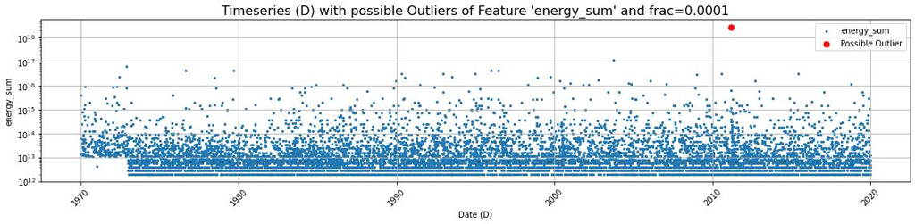

```
------------------------------------------------------------------------------------------------------------------------
Outliers Detection of Feature 'felt_mean' and frac=0.0001
There are 0 possible outliers.
```

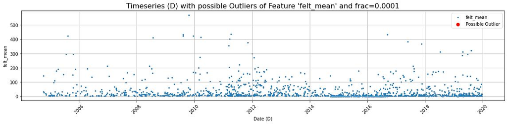

```
------------------------------------------------------------------------------------------------------------------------
Outliers Detection of Feature 'cdi_mean' and frac=0.0001
There are 0 possible outliers.
```

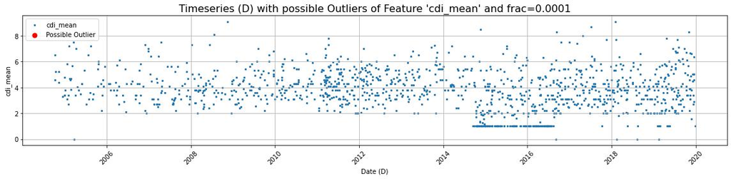

```
------------------------------------------------------------------------------------------------------------------------
Outliers Detection of Feature 'nst_mean' and frac=0.0001
There are 0 possible outliers.
```

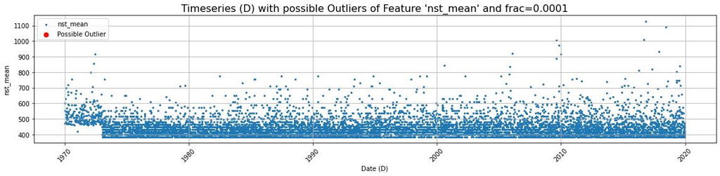

```
------------------------------------------------------------------------------------------------------------------------
Outliers Detection of Feature 'mmi_mean' and frac=0.0001
There are 0 possible outliers.
```

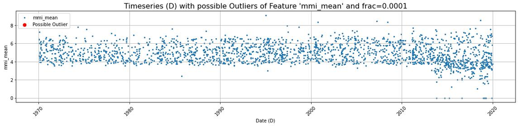

```python
settings_list = [
    {
        "column_to_analyze": ['energy_sum'],
        "outliers_fraction": 0.0001,
        "log_axis": True
    },{
        "column_to_analyze": ['felt_mean'],
        "outliers_fraction": 0.0001,
        "log_axis": False
    },{
        "column_to_analyze": ['cdi_mean'],
        "outliers_fraction": 0.0001,
        "log_axis": False
    },{
        "column_to_analyze": ['nst_mean'],
        "outliers_fraction": 0.0001,
        "log_axis": False
    },{
        "column_to_analyze": ['mmi_mean'],
        "outliers_fraction": 0.0001,
        "log_axis": False
    }
]

print("-"*120)
for settings in settings_list:
    column_to_analyze = settings["column_to_analyze"]
    outliers_fraction = settings["outliers_fraction"]
    log_axis = settings["log_axis"]
    analyze_outliers(eq_ts_daily_multi, column_to_analyze, outliers_fraction, log_axis)
```

## Generate resampled timeseries

```python
# resample to weekly frequency and aggregate
eq_ts_weekly_multi = eq_ts_daily_multi.resample('W').agg({
    'count': 'sum',
    'mag_max': 'max',
    'energy_sum': 'sum',
    'energy_max': 'max',
    'tsunami_sum': 'sum',
    'felt_mean': 'mean',
    'cdi_mean': 'mean',
    'nst_mean': 'mean',
    'mmi_mean': 'mean',
})
print("Weekly")
display(eq_ts_weekly_multi)

# resample to monthly frequency and aggregate
eq_ts_monthly_multi = eq_ts_daily_multi.resample('M').agg({
    'count': 'sum',
    'mag_max': 'max',
    'energy_sum': 'sum',
    'energy_max': 'max',
    'tsunami_sum': 'sum',
    'felt_mean': 'mean',
    'cdi_mean': 'mean',
    'nst_mean': 'mean',
    'mmi_mean': 'mean',
})
print("Monthly")
display(eq_ts_monthly_multi)

# resample to yearly frequency and aggregate
eq_ts_yearly_multi = eq_ts_daily_multi.resample('Y').agg({
    'count': 'sum',
    'mag_max': 'max',
    'energy_sum': 'sum',
    'energy_max': 'max',
    'tsunami_sum': 'sum',
    'felt_mean': 'mean',
    'cdi_mean': 'mean',
    'nst_mean': 'mean',
    'mmi_mean': 'mean',
})
print("Yearly")
display(eq_ts_yearly_multi)
```

```
Weekly
```

| timeymd | count | mag_max | energy_sum | energy_max | tsunami_sum | felt_mean | cdi_mean | nst_mean | mmi_mean |
| --- | --- | --- | --- | --- | --- | --- | --- | --- | --- |
| 1970-01-04 | 1.0 | 5.54 | 1.288250e+13 | 1.288250e+13 | 0.0 | NaN | NaN | 472.000000 | NaN |
| 1970-01-11 | 5.0 | 7.20 | 4.105508e+15 | 3.981072e+15 | 0.0 | NaN | NaN | 543.222222 | 5.548 |
| 1970-01-18 | 0.0 | NaN | 0.000000e+00 | NaN | 0.0 | NaN | NaN | NaN | NaN |
| ... | ... | ... | ... | ... | ... | ... | ... | ... | ... |
| 2019-12-22 | 8.0 | 5.40 | 2.554217e+13 | 7.943282e+12 | 0.0 | 15.555556 | 4.177778 | 403.833333 | 6.817 |
| 2019-12-29 | 4.0 | 5.40 | 1.475219e+13 | 7.943282e+12 | 0.0 | 1.000000 | 1.000000 | 408.833333 | 3.748 |
| 2020-01-05 | 0.0 | NaN | 0.000000e+00 | NaN | 0.0 | NaN | NaN | NaN | NaN |

2610 rows × 9 columns

```
Monthly
```

| timeymd | count | mag_max | energy_sum | energy_max | tsunami_sum | felt_mean | cdi_mean | nst_mean | mmi_mean |
| --- | --- | --- | --- | --- | --- | --- | --- | --- | --- |
| 1970-01-31 | 7.0 | 7.20 | 4.369579e+15 | 3.981072e+15 | 0.0 | NaN | NaN | 546.333333 | 5.838333 |
| 1970-02-28 | 9.0 | 6.74 | 1.104120e+15 | 8.128305e+14 | 0.0 | NaN | NaN | 535.888889 | 5.044429 |
| 1970-03-31 | 13.0 | 6.83 | 1.959644e+15 | 1.109175e+15 | 0.0 | NaN | NaN | 533.636364 | 5.316200 |
| ... | ... | ... | ... | ... | ... | ... | ... | ... | ... |
| 2019-10-31 | 32.0 | 6.60 | 1.269593e+15 | 5.011872e+14 | 3.0 | 35.150000 | 4.987143 | 433.836806 | 5.620042 |
| 2019-11-30 | 53.0 | 7.10 | 3.372012e+15 | 2.818383e+15 | 1.0 | 13.500000 | 3.975000 | 428.697778 | 4.317458 |
| 2019-12-31 | 32.0 | 6.80 | 1.156004e+15 | 1.000000e+15 | 1.0 | 23.407407 | 3.942593 | 417.447222 | 4.016333 |

600 rows × 9 columns

```
Yearly
```

| timeymd | count | mag_max | energy_sum | energy_max | tsunami_sum | felt_mean | cdi_mean | nst_mean | mmi_mean |
| --- | --- | --- | --- | --- | --- | --- | --- | --- | --- |
| 1970-12-31 | 91.0 | 7.44 | 2.519240e+16 | 9.120108e+15 | 0.0 | NaN | NaN | 536.409910 | 5.266740 |
| 1971-12-31 | 94.0 | 7.12 | 8.518634e+15 | 3.019952e+15 | 0.0 | NaN | NaN | 511.360759 | 4.973946 |
| 1972-12-31 | 126.0 | 8.00 | 1.280219e+17 | 6.309573e+16 | 0.0 | NaN | NaN | 533.355590 | 5.187488 |
| ... | ... | ... | ... | ... | ... | ... | ... | ... | ... |
| 2017-12-31 | 245.0 | 7.30 | 1.147010e+16 | 5.623413e+15 | 4.0 | 39.175347 | 4.018403 | 447.586827 | 4.259686 |
| 2018-12-31 | 254.0 | 7.50 | 1.735234e+16 | 1.122018e+16 | 2.0 | 30.641209 | 3.729029 | 444.181081 | 4.143211 |
| 2019-12-31 | 357.0 | 7.30 | 2.266003e+16 | 5.623413e+15 | 9.0 | 31.951654 | 3.947492 | 448.540172 | 4.096278 |

50 rows × 9 columns

```
------------------------------------------------------------------------------------------------------------------------
Outliers Detection of Feature 'energy_sum' and frac=0.0001
There are 1 possible outliers.
```

| timeymd | count | mag_max | energy_sum | energy_max | tsunami_sum | felt_mean | cdi_mean | nst_mean | mmi_mean | is_outlier |
| --- | --- | --- | --- | --- | --- | --- | --- | --- | --- | --- |
| 2011-03-13 | 422.0 | 9.1 | 2.902721e+18 | 2.818383e+18 | 0.0 | 102.49 | 5.092667 | 447.177226 | 4.629995 | -1 |

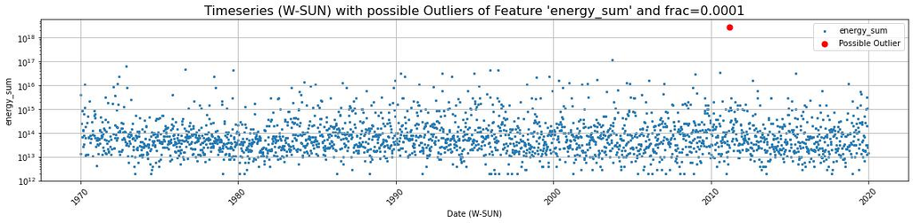

```
------------------------------------------------------------------------------------------------------------------------
Outliers Detection of Feature 'energy_sum' and frac=0.0001
There are 1 possible outliers.
```

| timeymd | count | mag_max | energy_sum | energy_max | tsunami_sum | felt_mean | cdi_mean | nst_mean | mmi_mean | is_outlier |
| --- | --- | --- | --- | --- | --- | --- | --- | --- | --- | --- |
| 2011-03-31 | 591.0 | 9.1 | 2.905239e+18 | 2.818383e+18 | 0.0 | 73.8725 | 4.432333 | 443.75311 | 4.913138 | -1 |

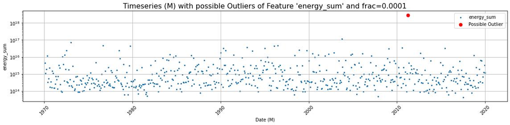

```
------------------------------------------------------------------------------------------------------------------------
Outliers Detection of Feature 'energy_sum' and frac=0.0001
There are 1 possible outliers.
```

| timeymd | count | mag_max | energy_sum | energy_max | tsunami_sum | felt_mean | cdi_mean | nst_mean | mmi_mean | is_outlier |
| --- | --- | --- | --- | --- | --- | --- | --- | --- | --- | --- |
| 2011-12-31 | 986.0 | 9.1 | 2.920848e+18 | 2.818383e+18 | 0.0 | 51.303388 | 4.204201 | 443.09167 | 5.033192 | -1 |

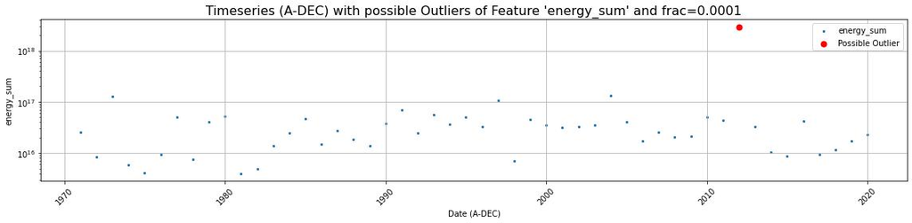

```
------------------------------------------------------------------------------------------------------------------------
Outliers Detection of Feature 'felt_mean' and frac=0.0001
There are 1 possible outliers.
```

| timeymd | count | mag_max | energy_sum | energy_max | tsunami_sum | felt_mean | cdi_mean | nst_mean | mmi_mean | is_outlier |
| --- | --- | --- | --- | --- | --- | --- | --- | --- | --- | --- |
| 2005-08-21 | 5.0 | 7.2 | 3.997810e+15 | 3.981072e+15 | 0.0 | 425.0 | 7.2 | 512.625 | 6.536 | -1 |

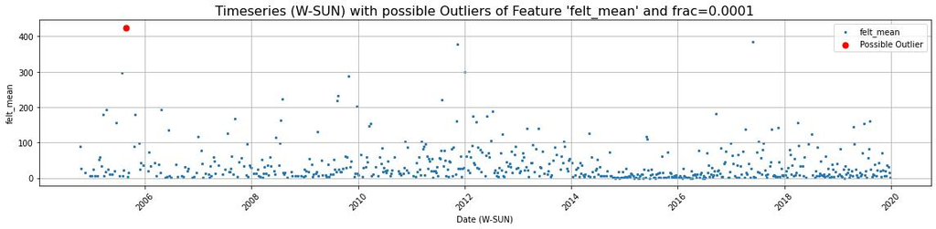

```
------------------------------------------------------------------------------------------------------------------------
Outliers Detection of Feature 'felt_mean' and frac=0.0001
There are 1 possible outliers.
```

| timeymd | count | mag_max | energy_sum | energy_max | tsunami_sum | felt_mean | cdi_mean | nst_mean | mmi_mean | is_outlier |
| --- | --- | --- | --- | --- | --- | --- | --- | --- | --- | --- |
| 2005-08-31 | 23.0 | 7.2 | 4.349241e+15 | 3.981072e+15 | 0.0 | 150.333333 | 4.633333 | 457.565476 | 5.5165 | -1 |

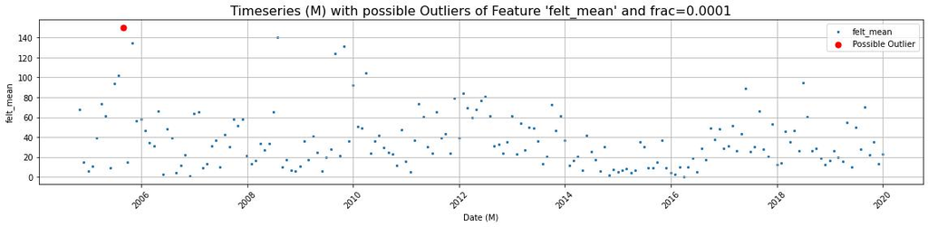

```
------------------------------------------------------------------------------------------------------------------------
Outliers Detection of Feature 'felt_mean' and frac=0.0001
There are 1 possible outliers.
```

| timeymd | count | mag_max | energy_sum | energy_max | tsunami_sum | felt_mean | cdi_mean | nst_mean | mmi_mean | is_outlier |
| --- | --- | --- | --- | --- | --- | --- | --- | --- | --- | --- |
| 2005-12-31 | 224.0 | 7.2 | 1.716801e+16 | 3.981072e+15 | 0.0 | 68.328947 | 4.417105 | 456.020238 | 5.118588 | -1 |

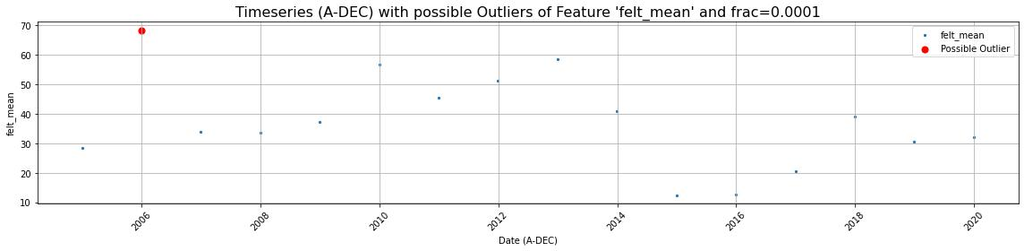

```
------------------------------------------------------------------------------------------------------------------------
Outliers Detection of Feature 'cdi_mean' and frac=0.0001
There are 1 possible outliers.
```

| timeymd | count | mag_max | energy_sum | energy_max | tsunami_sum | felt_mean | cdi_mean | nst_mean | mmi_mean | is_outlier |
| --- | --- | --- | --- | --- | --- | --- | --- | --- | --- | --- |
| 2008-11-16 | 5.0 | 7.4 | 7.975165e+15 | 7.943282e+15 | 0.0 | 6.0 | 9.1 | 461.111111 | 5.053333 | -1 |

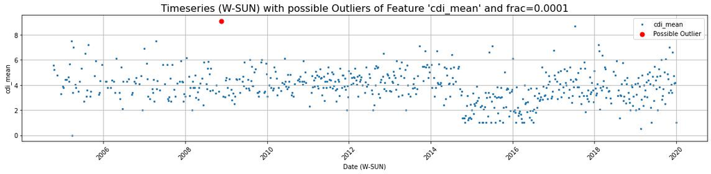

```
------------------------------------------------------------------------------------------------------------------------
Outliers Detection of Feature 'cdi_mean' and frac=0.0001
There are 1 possible outliers.
```

| timeymd | count | mag_max | energy_sum | energy_max | tsunami_sum | felt_mean | cdi_mean | nst_mean | mmi_mean | is_outlier |
| --- | --- | --- | --- | --- | --- | --- | --- | --- | --- | --- |
| 2008-11-30 | 15.0 | 7.4 | 8.172082e+15 | 7.943282e+15 | 0.0 | 6.0 | 9.1 | 449.444444 | 5.053333 | -1 |

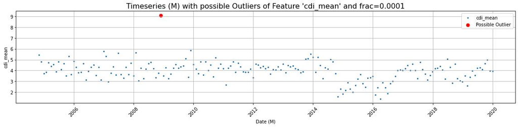

```
------------------------------------------------------------------------------------------------------------------------
Outliers Detection of Feature 'cdi_mean' and frac=0.0001
There are 1 possible outliers.
```

| timeymd | count | mag_max | energy_sum | energy_max | tsunami_sum | felt_mean | cdi_mean | nst_mean | mmi_mean | is_outlier |
| --- | --- | --- | --- | --- | --- | --- | --- | --- | --- | --- |
| 2014-12-31 | 301.0 | 7.1 | 8.811601e+15 | 2.818383e+15 | 6.0 | 12.453834 | 2.936936 | 434.101805 | 4.226231 | -1 |

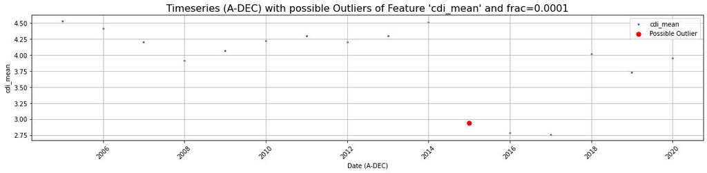

```
------------------------------------------------------------------------------------------------------------------------
Outliers Detection of Feature 'nst_mean' and frac=0.0001
There are 1 possible outliers.
```

| timeymd | count | mag_max | energy_sum | energy_max | tsunami_sum | felt_mean | cdi_mean | nst_mean | mmi_mean | is_outlier |
| --- | --- | --- | --- | --- | --- | --- | --- | --- | --- | --- |
| 2009-08-09 | 3.0 | 7.1 | 2.909503e+15 | 2.818383e+15 | 0.0 | 218.75 | 4.325 | 742.5 | 4.299 | -1 |

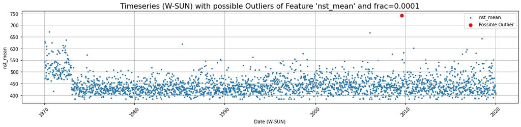

```
------------------------------------------------------------------------------------------------------------------------
Outliers Detection of Feature 'nst_mean' and frac=0.0001
There are 1 possible outliers.
```

| timeymd | count | mag_max | energy_sum | energy_max | tsunami_sum | felt_mean | cdi_mean | nst_mean | mmi_mean | is_outlier |
| --- | --- | --- | --- | --- | --- | --- | --- | --- | --- | --- |
| 1972-01-31 | 8.0 | 7.3 | 1.034356e+16 | 5.623413e+15 | 0.0 | NaN | NaN | 604.5 | 5.37975 | -1 |

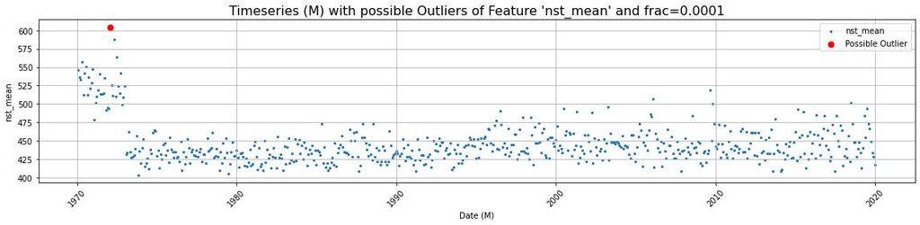

```
------------------------------------------------------------------------------------------------------------------------
Outliers Detection of Feature 'nst_mean' and frac=0.0001
There are 1 possible outliers.
```

| timeymd | count | mag_max | energy_sum | energy_max | tsunami_sum | felt_mean | cdi_mean | nst_mean | mmi_mean | is_outlier |
| --- | --- | --- | --- | --- | --- | --- | --- | --- | --- | --- |
| 1971-12-31 | 94.0 | 7.12 | 8.518634e+15 | 3.019952e+15 | 0.0 | NaN | NaN | 511.360759 | 4.973946 | -1 |

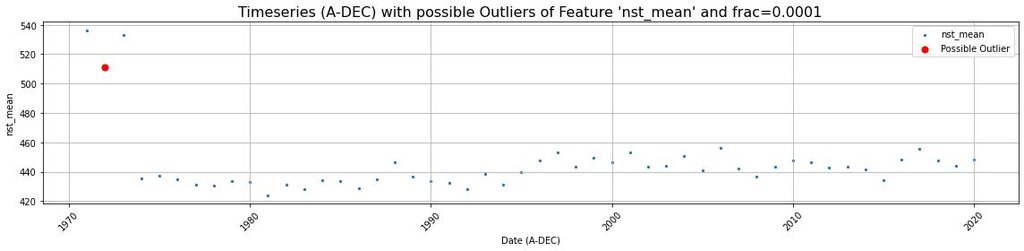

```
------------------------------------------------------------------------------------------------------------------------
Outliers Detection of Feature 'mmi_mean' and frac=0.0001
There are 1 possible outliers.
```

| timeymd | count | mag_max | energy_sum | energy_max | tsunami_sum | felt_mean | cdi_mean | nst_mean | mmi_mean | is_outlier |
| --- | --- | --- | --- | --- | --- | --- | --- | --- | --- | --- |
| 2013-10-27 | 10.0 | 7.1 | 2.867659e+15 | 2.818383e+15 | 1.0 | 61.666667 | 4.333333 | 452.344444 | 0.87725 | -1 |

[3 more figures not shown]

```python
print("-"*120)
for settings in settings_list:
    column_to_analyze = settings["column_to_analyze"]
    outliers_fraction = settings["outliers_fraction"]
    log_axis = settings["log_axis"]
    analyze_outliers(eq_ts_weekly_multi, column_to_analyze, outliers_fraction, log_axis)
    analyze_outliers(eq_ts_monthly_multi, column_to_analyze, outliers_fraction, log_axis)
    analyze_outliers(eq_ts_yearly_multi, column_to_analyze, outliers_fraction, log_axis)
```

## Check timeseries dates according to timespan

All data must be within the set timeframe, which is otherwise being corrected.

```python
# set all timeseries names for saving and loading
ts_names = ["eq_ts_daily_multi", "eq_ts_weekly_multi", "eq_ts_monthly_multi", "eq_ts_yearly_multi"]
```

```python
# show timeseries summaries by defining a list of the datframe names
# and running a loop over this list to show the timeseries summaries
# by evaluating the names and getting the summaries as a dictionary
for name in ts_names:
    ts = eval(name)
    summary = summarize_time_series(ts)  # Call the function
    #print(f"Timeseries summary for {name}:\n{summary}, Freq: {pd.infer_freq(ts.index)}\n")
    print(f"Timeseries summary for {name}:\n{summary}")
    print(f"Type: {type(ts)}\n")
```

```
Timeseries summary for eq_ts_daily_multi:
{'number_of_entries': 18262, 'first_date': Timestamp('1970-01-01 00:00:00', freq='D'), 'last_date': Timestamp('2019-12-31 00:00:00', freq='D'), 'ts_type': <class 'pandas.core.frame.DataFrame'>, 'ts_freq_index': <Day>, 'ts_freq_inferred': 'D'}
Type: <class 'pandas.core.frame.DataFrame'>

Timeseries summary for eq_ts_weekly_multi:
{'number_of_entries': 2610, 'first_date': Timestamp('1970-01-04 00:00:00', freq='W-SUN'), 'last_date': Timestamp('2020-01-05 00:00:00', freq='W-SUN'), 'ts_type': <class 'pandas.core.frame.DataFrame'>, 'ts_freq_index': <Week: weekday=6>, 'ts_freq_inferred': 'W-SUN'}
Type: <class 'pandas.core.frame.DataFrame'>

Timeseries summary for eq_ts_monthly_multi:
{'number_of_entries': 600, 'first_date': Timestamp('1970-01-31 00:00:00', freq='M'), 'last_date': Timestamp('2019-12-31 00:00:00', freq='M'), 'ts_type': <class 'pandas.core.frame.DataFrame'>, 'ts_freq_index': <MonthEnd>, 'ts_freq_inferred': 'M'}
Type: <class 'pandas.core.frame.DataFrame'>

Timeseries summary for eq_ts_yearly_multi:
{'number_of_entries': 50, 'first_date': Timestamp('1970-12-31 00:00:00', freq='A-DEC'), 'last_date': Timestamp('2019-12-31 00:00:00', freq='A-DEC'), 'ts_type': <class 'pandas.core.frame.DataFrame'>, 'ts_freq_index': <YearEnd: month=12>, 'ts_freq_inferred': 'A-DEC'}
Type: <class 'pandas.core.frame.DataFrame'>
```

All start- and end-dates of all timeseries are within the set timeframe or set to the next available date according to the timeseries generation and re-indexing.

## Save data

### Multivariate timeseries

```python
# iterate over the timeseries names to save, eval the names and call save_timeseries function, part 1
for name in ts_names:
    ts = eval(name)
    save_timeseries(
        data_file=f"{name}.csv",
        data_dir=data_ts_dir_cluster,
        data_set=ts,
        append_datetime=False,
        overwrite_file=True
    )

# iterate over the timeseries names to save, eval the names and call save_timeseries function, part 2
for name in ts_names:
    ts = eval(name)
    save_timeseries(
        data_file=f"{name}.csv",
        data_dir=data_ts_dir_cluster,
        data_set=ts,
        append_datetime=True,
        overwrite_file=False
    )
```

```
2025-01-22 22:07:55,427 - INFO - save_dataset: Timeseries saved successfully to 'data/scope/gvp_1000/cluster_western_pacific/eq_ts_daily_multi.csv'.
2025-01-22 22:07:55,450 - INFO - save_dataset: Timeseries saved successfully to 'data/scope/gvp_1000/cluster_western_pacific/eq_ts_weekly_multi.csv'.
2025-01-22 22:07:55,457 - INFO - save_dataset: Timeseries saved successfully to 'data/scope/gvp_1000/cluster_western_pacific/eq_ts_monthly_multi.csv'.
2025-01-22 22:07:55,459 - INFO - save_dataset: Timeseries saved successfully to 'data/scope/gvp_1000/cluster_western_pacific/eq_ts_yearly_multi.csv'.
2025-01-22 22:07:55,577 - INFO - save_dataset: Timeseries saved successfully to 'data/scope/gvp_1000/cluster_western_pacific/eq_ts_daily_multi_250122-220755.csv'.
2025-01-22 22:07:55,599 - INFO - save_dataset: Timeseries saved successfully to 'data/scope/gvp_1000/cluster_western_pacific/eq_ts_weekly_multi_250122-220755.csv'.
2025-01-22 22:07:55,606 - INFO - save_dataset: Timeseries saved successfully to 'data/scope/gvp_1000/cluster_western_pacific/eq_ts_monthly_multi_250122-220755.csv'.
2025-01-22 22:07:55,608 - INFO - save_dataset: Timeseries saved successfully to 'data/scope/gvp_1000/cluster_western_pacific/eq_ts_yearly_multi_250122-220755.csv'.
```

### Enriched earthquake datasets

```python
# save earthquake dataset, part 1
save_dataset(data_file = "earthquakes_enriched.csv",
             data_dir = data_dir_cluster,
             data_set = earthquakes_enriched,
             append_datetime=False,
             overwrite_file=True
            )

# save earthquake dataset, part 2
save_dataset(data_file = "earthquakes_enriched.csv",
             data_dir = data_dir_cluster,
             data_set = earthquakes_enriched,
             append_datetime=True,
             overwrite_file=False
            )
```

```
2025-01-22 22:07:55,835 - INFO - save_dataset: Data saved successfully to 'data/scope/gvp_1000/cluster_western_pacific/earthquakes_enriched.csv'.
2025-01-22 22:07:56,054 - INFO - save_dataset: Data saved successfully to 'data/scope/gvp_1000/cluster_western_pacific/earthquakes_enriched_250122-220755.csv'.
```

## End of script

```python
# log the end of this script
logging.info(f"End of script '{script_name}'.")
```

```
2025-01-22 22:07:56,060 - INFO - End of script '30_create_earthquake_timeseries.ipynb'.
```

## Appendix

```python
%%js

// -------------------------------------------
// What are the headings of this document?
// --> Get a better overview of the structure.
// -------------------------------------------

function listHeadings() {
    let headings = [];
    let cells = Jupyter.notebook.get_cells();

    cells.forEach((cell) => {
        if (cell.cell_type == 'markdown') {
            let text = cell.get_text();
            let lines = text.split('\n');

            lines.forEach((line) => {
                let match = line.match(/^(#+)\s+(.*)/);
                if (match) {
                    headings.push({
                        level: match[1].length, // Number of # symbols indicates the heading level
                        text: match[2].trim()
                    });
                }
            });
        }
    });
    return headings;
}

let headings = listHeadings();
headings.forEach((heading) => {
    let markdown = `${'#'.repeat(heading.level)} ${heading.text}`;
    element.append(`${markdown}<br>`);
});
```

```python
#from sklearn.preprocessing import StandardScaler, MinMaxScaler
#scaler = StandardScaler()
#eq_ts_yearly_multi_outlier['energy_sum_scaled'] = scaler.fit_transform(eq_ts_yearly_multi_outlier[['energy_sum']])
#display(eq_ts_yearly_multi_outlier)
```

## Save notebook as experimentation protocol

```python
# save notebook as a experimentation protocol
time.sleep(2)
display(Javascript('IPython.notebook.save_checkpoint();'))
time.sleep(2)
save_notebook_as_html(script_name, data_dir_cluster)
```